# Part I - (Prosper Loan Dataset Exploration)

## by (Carmel Prosper SAGBO)

## Introduction

> I choosed to work with Prosper Loan Data. This data set contain **113 937** loan with 81 variables to describe each observation. Inside the dataset we have information about the borrower, the loan status, the loan amount, the income for each employee, among others.

### Exploratory Goal

> At first Step we will explore our dataset to understand then :
> - Select feature(s) of interest that we will use for the vizualization process
> - Select features in the dataset that will help support our investigation into your feature(s) of interest

```python
# import all packages and set plots to be embedded inline
import numpy as np
import pandas as pd
import matplotlib.pyplot as plt
import seaborn as sns

%matplotlib inline
```

> Load in your dataset and describe its properties through the questions below. Try and motivate your exploration goals through this section.

```python
df = pd.read_csv('prosperLoanData.csv')
```

### What is the structure of your dataset?

```python
# First we are trying to get information on the dataset
df.info()
```

```
<class 'pandas.core.frame.DataFrame'>
RangeIndex: 113937 entries, 0 to 113936
Data columns (total 81 columns):
 #   Column                               Non-Null Count   Dtype
---  ------                               --------------   -----
 0   ListingKey                           113937 non-null  object
 1   ListingNumber                        113937 non-null  int64
 2   ListingCreationDate                  113937 non-null  object
 3   CreditGrade                          28953 non-null   object
 4   Term                                 113937 non-null  int64
 5   LoanStatus                           113937 non-null  object
 6   ClosedDate                           55089 non-null   object
 7   BorrowerAPR                          113912 non-null  float64
 8   BorrowerRate                         113937 non-null  float64
 9   LenderYield                          113937 non-null  float64
```

[output cut: 73 more lines]

#### With this huge number of observation we need to explore the dataset using a heatmap

Let's then create a function to plot the heatmap for null values

```python
"""
    heatmap_isna - Plot a heatmap with seaborn.
    df: The dataset used to make the plotting
"""
def heatmap_isna(df):
    plt.figure(figsize=(20,10))
    sns.heatmap(df.isna(), cbar=False)
```

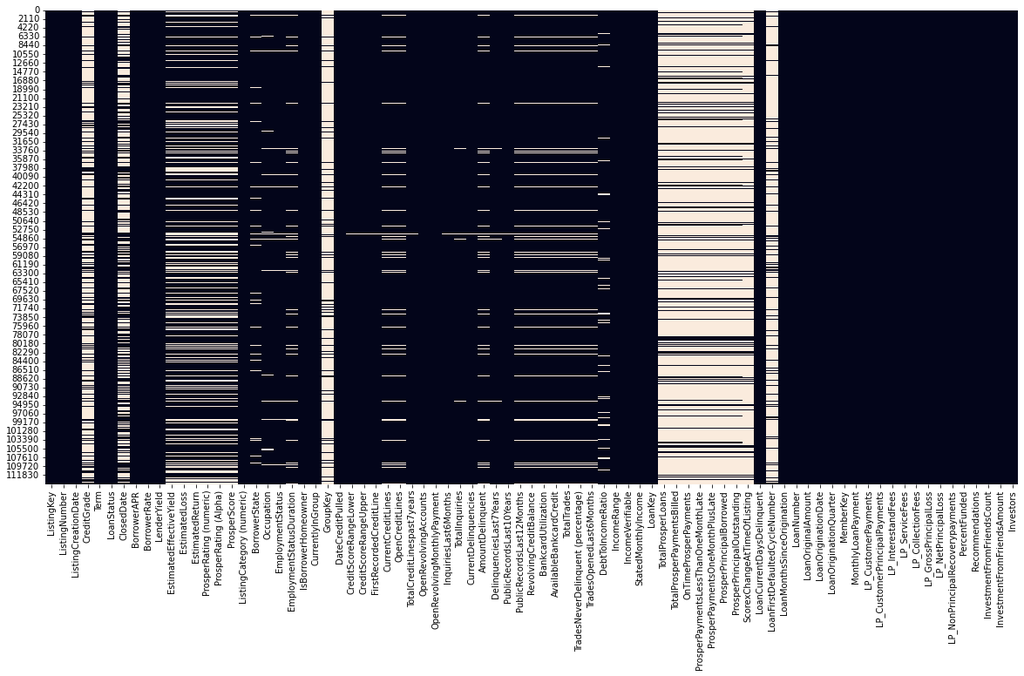

```python
# Ploting the heatmap help us to know much more about missing values
heatmap_isna(df)
```

```python
# Now Looking at this result let us check the ratio of these missing values
```

```python
pd.set_option('display.max_rows', 300)
pd.set_option('display.max_columns', 300)
(df.isnull().sum()/len(df)*100).sort_values(ascending=False)
```

```
GroupKey                               88.290898
LoanFirstDefaultedCycleNumber          85.121602
ScorexChangeAtTimeOfListing            83.387311
ProsperPrincipalOutstanding            80.616481
ProsperPrincipalBorrowed               80.616481
ProsperPaymentsOneMonthPlusLate        80.616481
ProsperPaymentsLessThanOneMonthLate    80.616481
OnTimeProsperPayments                  80.616481
TotalProsperLoans                      80.616481
TotalProsperPaymentsBilled             80.616481
CreditGrade                            74.588588
ClosedDate                             51.649596
ProsperRating (Alpha)                  25.526387
ProsperScore                           25.526387
EstimatedReturn                        25.526387
ProsperRating (numeric)                25.526387
EstimatedLoss                          25.526387
EstimatedEffectiveYield                25.526387
DebtToIncomeRatio                       7.507658
EmploymentStatusDuration                6.692295
AmountDelinquent                        6.689662
CurrentCreditLines                      6.673864
BankcardUtilization                     6.673864
PublicRecordsLast12Months               6.673864
OpenCreditLines                         6.673864
RevolvingCreditBalance                  6.673864
TotalTrades                             6.621203
TradesOpenedLast6Months                 6.621203
TradesNeverDelinquent (percentage)      6.621203
AvailableBankcardCredit                 6.621203
BorrowerState                           4.840394
Occupation                              3.149109
EmploymentStatus                        1.979164
TotalInquiries                          1.017229
DelinquenciesLast7Years                 0.868901
FirstRecordedCreditLine                 0.611742
PublicRecordsLast10Years                0.611742
TotalCreditLinespast7years              0.611742
CurrentDelinquencies                    0.611742
InquiriesLast6Months                    0.611742
```

[output cut: 27 more lines]

```
BorrowerRate                            0.000000
LenderYield                             0.000000
ListingCategory (numeric)               0.000000
IsBorrowerHomeowner                     0.000000
DateCreditPulled                        0.000000
LoanCurrentDaysDelinquent               0.000000
OpenRevolvingAccounts                   0.000000
OpenRevolvingMonthlyPayment             0.000000
ListingNumber                           0.000000
IncomeRange                             0.000000
IncomeVerifiable                        0.000000
StatedMonthlyIncome                     0.000000
LoanKey                                 0.000000
Investors                               0.000000
dtype: float64
```

```python
# Let us have a quick look at missing ratio description
(df.isnull().sum()/len(df)*100).describe()
```

```
count    81.000000
mean     14.780596
std      27.954859
min       0.000000
25%       0.000000
50%       0.518708
75%       6.689662
max      88.290898
dtype: float64
```

```python
# We will extract from the dataset all columns that have less than 15 percent values null to reduce the dataset
df = df[df.columns[(df.isnull().sum()/len(df)*100) < 15 ]]
df.sample(5)
```

|  | ListingKey | ListingNumber | ListingCreationDate | Term | LoanStatus | BorrowerAPR | BorrowerRate | LenderYield | ListingCategory (numeric) | BorrowerState | Occupation | EmploymentStatus | EmploymentStatusDuration | IsBorrowerHomeowner | CurrentlyInGroup | DateCreditPulled | CreditScoreRangeLower | CreditScoreRangeUpper | FirstRecordedCreditLine | CurrentCreditLines | OpenCreditLines | TotalCreditLinespast7years | OpenRevolvingAccounts | OpenRevolvingMonthlyPayment | InquiriesLast6Months | TotalInquiries | CurrentDelinquencies | AmountDelinquent | DelinquenciesLast7Years | … |
| --- | --- | --- | --- | --- | --- | --- | --- | --- | --- | --- | --- | --- | --- | --- | --- | --- | --- | --- | --- | --- | --- | --- | --- | --- | --- | --- | --- | --- | --- | --- |
| 87623 | A28035105662748842BF51B | 497941 | 2011-03-14 09:48:34.380000000 | 36 | Completed | 0.35643 | 0.3199 | 0.3099 | 7 | PA | Professional | Full-time | 41.0 | False | False | 2011-03-14 09:48:26 | 660.0 | 679.0 | 1999-03-31 00:00:00 | 11.0 | 10.0 | 30.0 | 7 | 567.0 | 0.0 | 13.0 | 0.0 | 0.0 | 0.0 | … |
| 18821 | 698234088526517234C47D2 | 256860 | 2007-12-28 10:48:13.927000000 | 36 | Completed | 0.26021 | 0.2450 | 0.2350 | 6 | CA | Other | Full-time | 13.0 | False | True | 2007-12-18 11:46:28.497000000 | 540.0 | 559.0 | 1994-05-19 00:00:00 | 10.0 | 8.0 | 33.0 | 6 | 161.0 | 1.0 | 6.0 | 19.0 | 3002.0 | 54.0 | … |
| 104962 | CF6F3540463901325C13D06 | 563577 | 2012-02-28 08:26:36.167000000 | 60 | Current | 0.20358 | 0.1845 | 0.1745 | 2 | NY | Doctor | Employed | 85.0 | True | False | 2012-02-28 08:26:31 | 660.0 | 679.0 | 1986-09-03 00:00:00 | 11.0 | 12.0 | 45.0 | 4 | 354.0 | 0.0 | 4.0 | 1.0 | 3222.0 | 5.0 | … |
| 97689 | FBCF356803919727225F7DF | 696759 | 2013-01-09 16:23:19.083000000 | 60 | Completed | 0.20081 | 0.1769 | 0.1669 | 1 | SC | Analyst | Employed | 2.0 | False | False | 2013-02-12 09:58:27 | 720.0 | 739.0 | 1998-01-23 00:00:00 | 19.0 | 18.0 | 50.0 | 19 | 797.0 | 3.0 | 6.0 | 0.0 | 0.0 | 9.0 | … |
| 41499 | 9FF63550060494112E37EBF | 600357 | 2012-06-15 18:07:46.303000000 | 36 | Current | 0.28851 | 0.2499 | 0.2399 | 7 | CO | Other | Other | 14.0 | True | False | 2012-06-15 18:07:42 | 780.0 | 799.0 | 1978-02-24 00:00:00 | 6.0 | 5.0 | 15.0 | 5 | 59.0 | 0.0 | 0.0 | 0.0 | 0.0 | 0.0 | … |

```python
df.shape
```

```
(113937, 63)
```

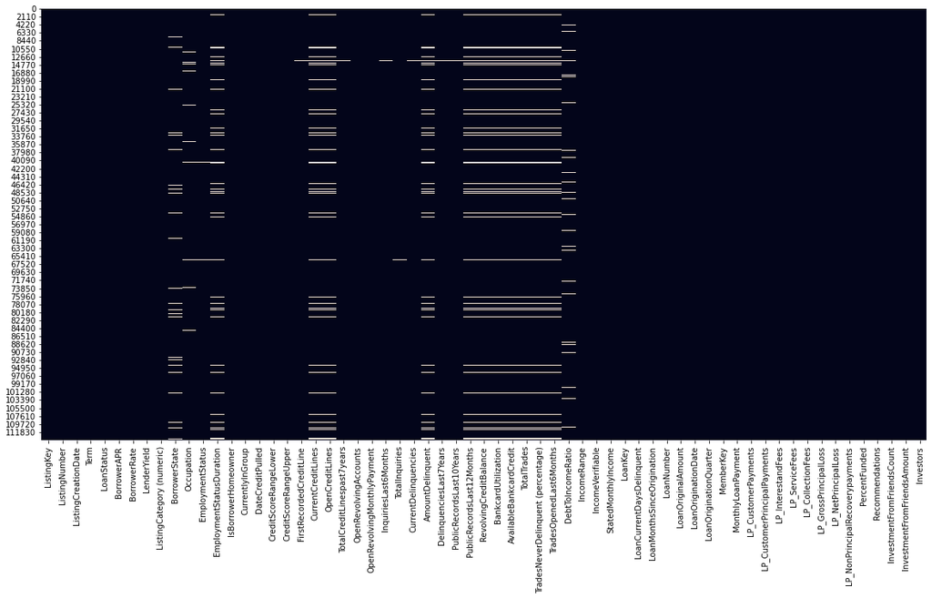

```python
heatmap_isna(df)
```

## Now we will explore the 63 remain features that remain

```python
for col in df.select_dtypes('int64'):
    print(f'{col :-<50}\n {df[col].describe()}\n')
```

```
ListingNumber-------------------------------------
 count    1.139370e+05
mean     6.278857e+05
std      3.280762e+05
min      4.000000e+00
25%      4.009190e+05
50%      6.005540e+05
75%      8.926340e+05
max      1.255725e+06
Name: ListingNumber, dtype: float64

Term----------------------------------------------
 count    113937.000000
mean         40.830248
std          10.436212
min          12.000000
25%          36.000000
50%          36.000000
75%          36.000000
max          60.000000
Name: Term, dtype: float64

ListingCategory (numeric)-------------------------
 count    113937.000000
mean          2.774209
std           3.996797
min           0.000000
25%           1.000000
50%           1.000000
75%           3.000000
max          20.000000
Name: ListingCategory (numeric), dtype: float64

OpenRevolvingAccounts-----------------------------
 count    113937.00000
mean          6.96979
std           4.63097
min           0.00000
25%           4.00000
50%           6.00000
```

[output cut: 65 more lines]

```
50%           0.000000
75%           0.000000
max          33.000000
Name: InvestmentFromFriendsCount, dtype: float64

Investors-----------------------------------------
 count    113937.000000
mean         80.475228
std         103.239020
min           1.000000
25%           2.000000
50%          44.000000
75%         115.000000
max        1189.000000
Name: Investors, dtype: float64
```

```python
for col in df.select_dtypes('float64'):
    print(f'{col :-<50}\n {df[col].describe()}\n')
```

```
BorrowerAPR---------------------------------------
 count    113912.000000
mean          0.218828
std           0.080364
min           0.006530
25%           0.156290
50%           0.209760
75%           0.283810
max           0.512290
Name: BorrowerAPR, dtype: float64

BorrowerRate--------------------------------------
 count    113937.000000
mean          0.192764
std           0.074818
min           0.000000
25%           0.134000
50%           0.184000
75%           0.250000
max           0.497500
Name: BorrowerRate, dtype: float64

LenderYield---------------------------------------
 count    113937.000000
mean          0.182701
std           0.074516
min          -0.010000
25%           0.124200
50%           0.173000
75%           0.240000
max           0.492500
Name: LenderYield, dtype: float64

EmploymentStatusDuration--------------------------
 count    106312.000000
mean         96.071582
std          94.480605
min           0.000000
25%          26.000000
50%          67.000000
```

[output cut: 340 more lines]

```
50%           1.000000
75%           1.000000
max           1.012500
Name: PercentFunded, dtype: float64

InvestmentFromFriendsAmount-----------------------
 count    113937.000000
mean         16.550751
std         294.545422
min           0.000000
25%           0.000000
50%           0.000000
75%           0.000000
max       25000.000000
Name: InvestmentFromFriendsAmount, dtype: float64
```

```python
for col in df.select_dtypes('object'):
    print(f'{col :-<50}\n {df[col].describe()}\n')
```

```
ListingKey----------------------------------------
 count                      113937
unique                     113066
top       17A93590655669644DB4C06
freq                            6
Name: ListingKey, dtype: object

ListingCreationDate-------------------------------
 count                            113937
unique                           113064
top       2013-10-02 17:20:16.550000000
freq                                  6
Name: ListingCreationDate, dtype: object

LoanStatus----------------------------------------
 count      113937
unique         12
top       Current
freq        56576
Name: LoanStatus, dtype: object

BorrowerState-------------------------------------
 count     108422
unique        51
top           CA
freq       14717
Name: BorrowerState, dtype: object

Occupation----------------------------------------
 count     110349
unique        67
top        Other
freq       28617
Name: Occupation, dtype: object

EmploymentStatus----------------------------------
 count       111682
unique           8
top       Employed
freq         67322
```

[output cut: 35 more lines]

```
Name: LoanOriginationDate, dtype: object

LoanOriginationQuarter----------------------------
 count      113937
unique         33
top       Q4 2013
freq        14450
Name: LoanOriginationQuarter, dtype: object

MemberKey-----------------------------------------
 count                      113937
unique                      90831
top       63CA34120866140639431C9
freq                            9
Name: MemberKey, dtype: object
```

```python
for col in df.select_dtypes('bool'):
    print(f'{col :-<50}\n {df[col].unique()}\n')
```

```
IsBorrowerHomeowner-------------------------------
 [ True False]

CurrentlyInGroup----------------------------------
 [ True False]

IncomeVerifiable----------------------------------
 [ True False]
```

```python
# The
df_main = df[['IsBorrowerHomeowner', 'IncomeVerifiable','IncomeRange', 'LoanStatus', 'Occupation', 'EmploymentStatus', 'LoanOriginalAmount','BorrowerRate','EmploymentStatusDuration', 'DebtToIncomeRatio','MonthlyLoanPayment', 'TotalCreditLinespast7years', 'DelinquenciesLast7Years']]
```

### What is/are the main feature(s) of interest in your dataset?

> **IsBorrowerHomeowner** : A Borrower will be classified as a homowner if they have a mortgage on their credit profile or provide documentation confirming they are a homeowner.

> **IncomeVerifiable** : The borrower indicated they have the required documentation to support their income.

> **IncomeRange** : The income range of the borrower at the time the listing was created.

> **LoanStatus** : The current status of the loan: Cancelled, Chargedoff, Completed, Current, Defaulted, FinalPaymentInProgress, PastDue. The PastDue status will be accompanied by a delinquency bucket.

> **Occupation** : The Occupation selected by the Borrower at the time they created the listing.

> **EmploymentStatus** : The employment status of the borrower at the time they posted the listing.

> **LoanOriginalAmount** : The origination amount of the loan.

> **BorrowerRate** : The Borrower's interest rate for this loan.

> **EmploymentStatusDuration** : EmploymentStatusDuration

> **DebtToIncomeRatio** : The debt to income ratio of the borrower at the time the credit profile was pulled. This value is Null if the debt to income ratio is not available. This value is capped at 10.01 (any debt to income ratio larger than 1000% will be returned as 1001%).

> **MonthlyLoanPayment** : The scheduled monthly loan payment.

> **TotalCreditLinespast7years** : Number of credit lines in the past seven years at the time the credit profile was pulled.

> **DelinquenciesLast7Years** : Number of delinquencies in the past 7 years at the time the credit profile was pulled.

### What features in the dataset do you think will help support your investigation into your feature(s) of interest?

> **LoanStatus** : The current status of the loan: Cancelled, Chargedoff, Completed, Current, Defaulted, FinalPaymentInProgress, PastDue. The PastDue status will be accompanied by a delinquency bucket.

> **Occupation** : The Occupation selected by the Borrower at the time they created the listing.

> **LoanOriginalAmount** : The origination amount of the loan.

> **MonthlyLoanPayment** : The scheduled monthly loan payment.

```python
df_main.sample(5)
```

|  | IsBorrowerHomeowner | IncomeVerifiable | IncomeRange | LoanStatus | Occupation | EmploymentStatus | LoanOriginalAmount | BorrowerRate | EmploymentStatusDuration | DebtToIncomeRatio | MonthlyLoanPayment | TotalCreditLinespast7years | DelinquenciesLast7Years |
| --- | --- | --- | --- | --- | --- | --- | --- | --- | --- | --- | --- | --- | --- |
| 35587 | True | True | $100,000+ | Current | Civil Service | Employed | 4000 | 0.3073 | 292.0 | 0.25 | 171.41 | 45.0 | 16.0 |
| 83557 | True | True | $50,000-74,999 | Current | Other | Employed | 15000 | 0.2468 | 5.0 | 0.37 | 437.46 | 20.0 | 0.0 |
| 62006 | True | True | $100,000+ | Current | Executive | Employed | 15000 | 0.1396 | 115.0 | 0.17 | 348.71 | 46.0 | 0.0 |
| 7339 | True | True | $50,000-74,999 | Completed | Professional | Employed | 8000 | 0.1902 | 384.0 | 0.29 | 293.33 | 38.0 | 4.0 |
| 93226 | True | True | $100,000+ | Chargedoff | Food Service | Self-employed | 25000 | 0.1400 | 63.0 | 0.10 | 854.44 | 12.0 | 0.0 |

```python
df_main.describe()
```

|  | LoanOriginalAmount | BorrowerRate | EmploymentStatusDuration | DebtToIncomeRatio | MonthlyLoanPayment | TotalCreditLinespast7years | DelinquenciesLast7Years |
| --- | --- | --- | --- | --- | --- | --- | --- |
| count | 113937.00000 | 113937.000000 | 106312.000000 | 105383.000000 | 113937.000000 | 113240.000000 | 112947.000000 |
| mean | 8337.01385 | 0.192764 | 96.071582 | 0.275947 | 272.475783 | 26.754539 | 4.154984 |
| std | 6245.80058 | 0.074818 | 94.480605 | 0.551759 | 192.697812 | 13.637871 | 10.160216 |
| min | 1000.00000 | 0.000000 | 0.000000 | 0.000000 | 0.000000 | 2.000000 | 0.000000 |
| 25% | 4000.00000 | 0.134000 | 26.000000 | 0.140000 | 131.620000 | 17.000000 | 0.000000 |
| 50% | 6500.00000 | 0.184000 | 67.000000 | 0.220000 | 217.740000 | 25.000000 | 0.000000 |
| 75% | 12000.00000 | 0.250000 | 137.000000 | 0.320000 | 371.580000 | 35.000000 | 3.000000 |
| max | 35000.00000 | 0.497500 | 755.000000 | 10.010000 | 2251.510000 | 136.000000 | 99.000000 |

```python
df_main.info()
```

```
<class 'pandas.core.frame.DataFrame'>
RangeIndex: 113937 entries, 0 to 113936
Data columns (total 13 columns):
 #   Column                      Non-Null Count   Dtype
---  ------                      --------------   -----
 0   IsBorrowerHomeowner         113937 non-null  bool
 1   IncomeVerifiable            113937 non-null  bool
 2   IncomeRange                 113937 non-null  object
 3   LoanStatus                  113937 non-null  object
 4   Occupation                  110349 non-null  object
 5   EmploymentStatus            111682 non-null  object
 6   LoanOriginalAmount          113937 non-null  int64
 7   BorrowerRate                113937 non-null  float64
 8   EmploymentStatusDuration    106312 non-null  float64
 9   DebtToIncomeRatio           105383 non-null  float64
 10  MonthlyLoanPayment          113937 non-null  float64
 11  TotalCreditLinespast7years  113240 non-null  float64
 12  DelinquenciesLast7Years     112947 non-null  float64
dtypes: bool(2), float64(6), int64(1), object(4)
memory usage: 9.8+ MB
```

## Univariate Exploration

> Exploration of our dataset using visualization

#### Question 1: Is Borrower Home owner ?

#### Visualization 1

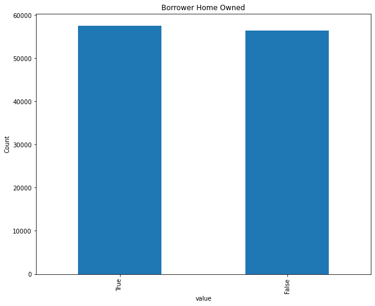

```python
plt.figure(figsize=(10,8))
df_main.IsBorrowerHomeowner.value_counts().plot(kind='bar')
plt.title('Borrower Home Owned')
plt.xlabel('value')
plt.ylabel('Count')
plt.show()
```

#### Observation 1:

> Arround **50%** percent of all loan have the Borrower as the owner of their house. In future exploration we will see if there is realation between this variable and the loan amount

#### Question 2 : Did all borrowers have their Income Verifiable

#### Visualization 2

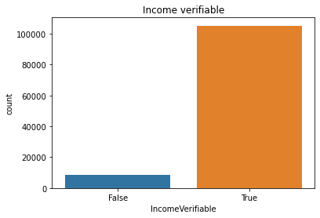

```python
sns.countplot(data= df_main, x = 'IncomeVerifiable').set_title('Income verifiable')
plt.show()
# Explore false group
```

#### Observation 2:

> Most of loans are recorded to people with income verifiable. We should discuss later about the case of people without verifiable income.

#### Question 3 : What are the distribution of Borrower Income Range ?

```python
df_main.IncomeRange.value_counts()
```

```
$25,000-49,999    32192
$50,000-74,999    31050
$100,000+         17337
$75,000-99,999    16916
Not displayed      7741
$1-24,999          7274
Not employed        806
$0                  621
Name: IncomeRange, dtype: int64
```

```python
df_main.IncomeRange.value_counts().index
```

```
Index(['$25,000-49,999', '$50,000-74,999', '$100,000+', '$75,000-99,999',
       'Not displayed', '$1-24,999', 'Not employed', '$0'],
      dtype='object')
```

#### Visualization 3

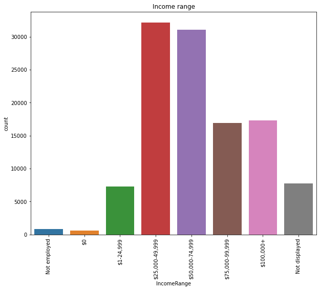

```python
order_income_range = ['Not employed', '$0','$1-24,999','$25,000-49,999', '$50,000-74,999', '$75,000-99,999', '$100,000+', 'Not displayed']
plt.figure(figsize=(10,8))
sns.countplot(data= df_main, x = 'IncomeRange', order= order_income_range).set_title('Income range')
plt.xticks(rotation=90)
plt.show()
```

#### Observation 3:

> The highest amount or number of loans are for people with salary greather or equal to **25,000**.

#### Question 4: Did Borrower keep their engagement by paying ?

> Loan Status Exploration

#### Visualization 4

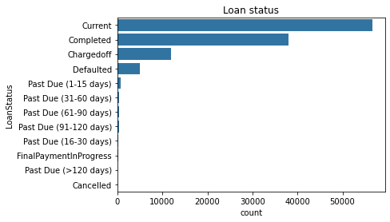

```python
colors =  sns.color_palette()[0]
loan_status_orders = df_main.LoanStatus.value_counts().index
sns.countplot(data= df_main, y = 'LoanStatus', color= colors, order=loan_status_orders).set_title('Loan status')
plt.show()
```

### Question 5: What is the distribution of Borrower Occupation ?

###### Other

> [nan, 'Other']

###### Religious

> ['Religious', 'Clergy', 'Clerical'],

###### Food And Services

> ['Food Service Management', 'Food Service', 'Social Worker', 'Waiter/Waitress']

###### Health And Science

> ['Scientist', 'Psychologist', 'Biologist', 'Chemist', 'Dentist', 'Doctor', 'Pharmacist', 'Medical Technician', 'Nurse (RN)', "Nurse's Aide", 'Nurse (LPN)']

##### Economy

> ['Pilot - Private/Commercial', 'Retail Management', 'Sales - Commission', 'Car Dealer', 'Attorney', 'Accountant/CPA', 'Investor']

###### Professional And Enginneering

> ['Engineer - Electrical', 'Architect', 'Engineer - Mechanical', 'Engineer - Chemical', 'Construction', 'Landscaping', 'Professional', 'Computer Programmer', 'Analyst']

###### Laborer

> ['Tradesman - Plumber', 'Tradesman - Carpenter', 'Tradesman - Electrician', 'Laborer', 'Skilled Labor', 'Tradesman - Mechanic', 'Homemaker', 'Truck Driver', 'Bus Driver']

###### Administrative

> ['Civil Service', 'Executive', 'Administrative Assistant', 'Postal Service', 'Military Enlisted', 'Judge', 'Police Officer/Correction Officer', 'Military Officer', 'Flight Attendant', 'Fireman', 'Realtor']

###### School Head

> ['Principal', "Teacher's Aide", 'Professor', 'Teacher']

> ['Student - College Senior','Student - College Junior', 'Student - College Graduate Student', 'Student - Technical School', 'Student - Community College', 'Student - College Freshman', 'Student - College Sophomore']

```python
""" Create Occupation Group with existing Occupation in a dataset"""
def occupation_group(df):
    if df['Occupation'] in['Food Service Management', 'Food Service', 'Social Worker', 'Waiter/Waitress']:
        return 'Food And Services'
    elif df['Occupation'] in['Scientist', 'Psychologist', 'Biologist', 'Chemist', 'Dentist', 'Doctor', 'Pharmacist', 'Medical Technician', 'Nurse (RN)',  "Nurse's Aide",  'Nurse (LPN)']:
        return 'Health And Science'
    elif df['Occupation'] in ['Pilot - Private/Commercial',  'Retail Management', 'Sales - Commission', 'Car Dealer', 'Attorney', 'Accountant/CPA', 'Investor']:
        return 'Economy'
    elif df['Occupation'] in ['Engineer - Electrical', 'Architect', 'Engineer - Mechanical',  'Engineer - Chemical', 'Construction', 'Landscaping', 'Professional', 'Computer Programmer', 'Analyst']:
        return 'Professional And Enginneering'
    elif df['Occupation'] in ['Tradesman - Plumber', 'Tradesman - Carpenter', 'Tradesman - Electrician', 'Laborer', 'Skilled Labor', 'Tradesman - Mechanic', 'Homemaker',  'Truck Driver', 'Bus Driver']:
        return 'Laborer'
    elif df['Occupation'] in ['Civil Service', 'Executive', 'Administrative Assistant',  'Postal Service', 'Military Enlisted', 'Judge',  'Police Officer/Correction Officer', 'Military Officer',  'Flight Attendant', 'Fireman', 'Realtor']:
        return 'Administrative'
    elif df['Occupation'] in ['Principal', "Teacher's Aide",  'Professor', 'Teacher']:
        return 'School Head'
    elif df['Occupation'] in ['Student - College Senior','Student - College Junior', 'Student - College Graduate Student', 'Student - Technical School',  'Student - Community College', 'Student - College Freshman', 'Student - College Sophomore']:
        return 'School Head'
    elif df['Occupation'] in ['Religious', 'Clergy', 'Clerical']:
        return 'Religious'
    else:
        return 'Other'

df_main['OccuGroup'] = df_main.apply(occupation_group, axis=1)
df_main['OccuGroup'].value_counts()
```

```
Other                            35002
Professional And Enginneering    26703
Administrative                   14389
Economy                          10920
Laborer                           8102
Health And Science                6195
School Head                       5603
Food And Services                 3539
Religious                         3484
Name: OccuGroup, dtype: int64
```

#### Visualization 5

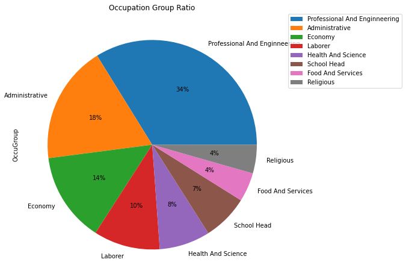

```python
plt.figure(figsize=(10,8))
df_main[df_main.OccuGroup != "Other"]['OccuGroup'].value_counts().plot(kind='pie', autopct='%.0f%%')
plt.title('Occupation Group Ratio')
plt.legend(bbox_to_anchor=(1.02, 1), loc='upper left', borderaxespad=0)
plt.show()
```

#### Observation 5:

> With the Occupation variable we have many occupation, so to able to have a view through it we change it to group of ocuppation. Like that we are able to get an observation and most of loans have known jobs classified in groups above. Engineers are the most getting loans.

#### Question 6 : Are all our Borrowers in good situation with their Employment Status ?

#### Visualization 6

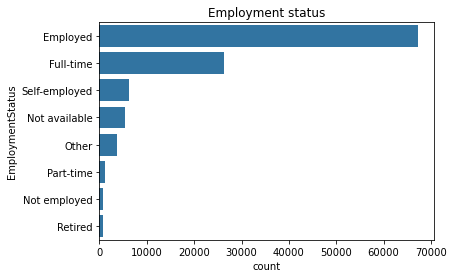

```python
colors = sns.color_palette()[0]
employment_status_orders = df_main.EmploymentStatus.value_counts().index
sns.countplot(data= df_main, y = 'EmploymentStatus', color= colors, order=employment_status_orders).set_title('Employment status')
plt.show()
```

#### Question 7 What distribution is the Loan Original Amount following

#### Visualization 7

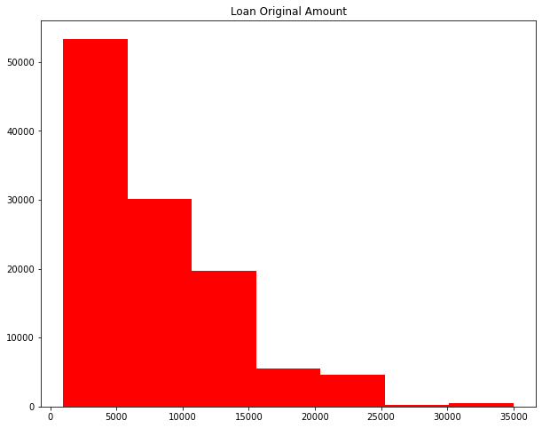

```python
plt.figure(figsize=(10,8))
plt.hist(df_main.LoanOriginalAmount, color='r', bins=7)
plt.title('Loan Original Amount')
plt.show()
```

#### Observation 7:

> Observing the distribution of loans amount we can say that the loan hug less risk. Only few persons have huge loan.

#### Question 8 Is the Loan company getting good income based on the BorrowerRate

#### Visualization 8

```python
df_main.BorrowerRate.describe()
```

```
count    113937.000000
mean          0.192764
std           0.074818
min           0.000000
25%           0.134000
50%           0.184000
75%           0.250000
max           0.497500
Name: BorrowerRate, dtype: float64
```

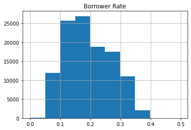

```python
df_main.BorrowerRate.hist()
plt.title('Borrower Rate')
plt.show()
```

#### Observation 8:

> The borrower rate often between 5% and 40%. But we also have a specific case of 50%

#### Question 9: Read the Employment Status Duration distribution in month?

#### Visualization 9

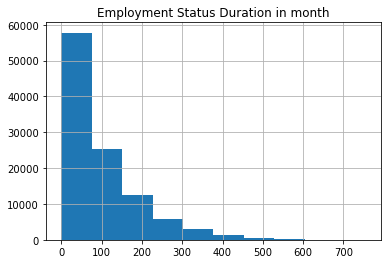

```python
# sns.countplot(data= df_main, x = 'EmploymentStatusDuration', color= colors)
df_main.EmploymentStatusDuration.hist()
plt.title('Employment Status Duration in month')
plt.show()
```

#### DebtToIncomeRatio

```python
df_main.DebtToIncomeRatio.sort_values(ascending=False)
```

```
60894     10.01
59733     10.01
70843     10.01
20524     10.01
113626    10.01
          ...
113893      NaN
113894      NaN
113899      NaN
113903      NaN
113908      NaN
Name: DebtToIncomeRatio, Length: 113937, dtype: float64
```

#### Question 10 : what are the company getting as Monthly Loan Payment.

#### Visualization 10

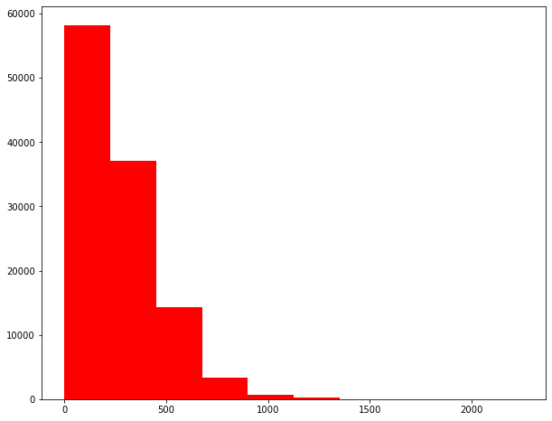

```python
plt.figure(figsize=(10,8))
plt.hist(df_main.MonthlyLoanPayment, color='r', bins = 10)
plt.show()
```

#### Question 11 : Are they giving loan to people with existing Credit Lines during the past 7 years ?

#### Visualization 11

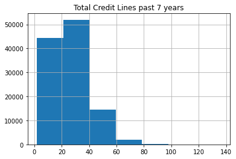

```python
df_main.TotalCreditLinespast7years.hist(bins=7)
plt.title('Total Credit Lines past 7 years')
plt.show()
```

#### Observation 11:

> The borrowers are people known with certains number of credit so, with some rate of trust.

#### Question 12 : Is there an error giving loan to people with high rate of delinquencies during the last 7 Years ?

#### Visualization 12

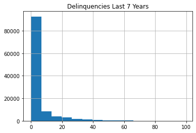

```python
df_main.DelinquenciesLast7Years.hist(bins=15)
plt.title('Delinquencies Last 7 Years')
plt.show()
```

### Discuss the distribution(s) of your variable(s) of interest. Were there any unusual points? Did you need to perform any transformations?

> We have registered three variables of interest: Means **Occupation, LoanOriginalAmount and MonthlyLoanPayment**. During our exploration we have found that most of 69% of all our dataset have known and classified work as Occupation, And to be able to get this information we transformed Occupation into group. Now to get more about the relation let's dive into some observations with Bivariate exploratio and possible multivariate to get a better understand.

> The Prosper Loan company really care about the delinquencies, and trust also people that already have a number of existing Credit line.

### Of the features you investigated, were there any unusual distributions? Did you perform any operations on the data to tidy, adjust, or change the form of the data? If so, why did you do this?

> With our exploration, there were some difficulty with salary range for plotting resolved by using custum order when plotting. we have also perfomed a new column named **OccuGroup** for **Occupation** in order to appreciate the distribution of loan among all group or class of Borrower.

```python
### For the remains analysys we are changing the dataset to look only for those with known Occupation
df_main = df_main[df_main.OccuGroup != "Other"]
```

## Bivariate Exploration

> In this section, investigate relationships between pairs of variables in your data. Make sure the variables that you cover here have been introduced in some fashion in the previous section (univariate exploration).

#### Question 1: How does evolve the loan based on the Occupation Group of Borrowers

#### Visualization 1:

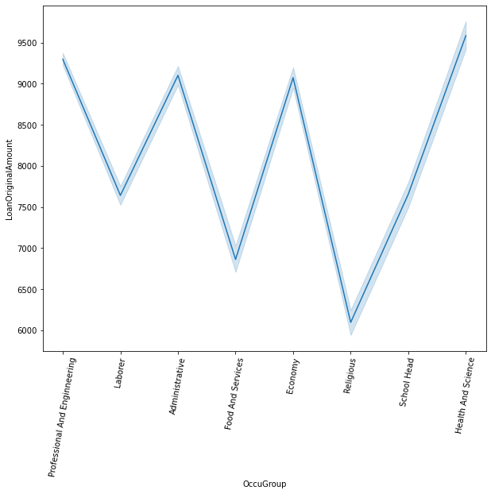

```python
# df_main.groupby('OccuGroup').LoanOriginalAmount.hist()
plt.figure(figsize=(10,8))
sns.lineplot(x=df_main.OccuGroup, y=df_main.LoanOriginalAmount, palette=colors)
plt.xticks(rotation=80)
plt.show()
```

#### Observation 1:

> The most in demand and highest group in need of loans are : (Health And Science, Professional And Engineering)

#### Question 2 : Did Borrower paying enough to company cover lost found based on Interest

#### Visualization 2

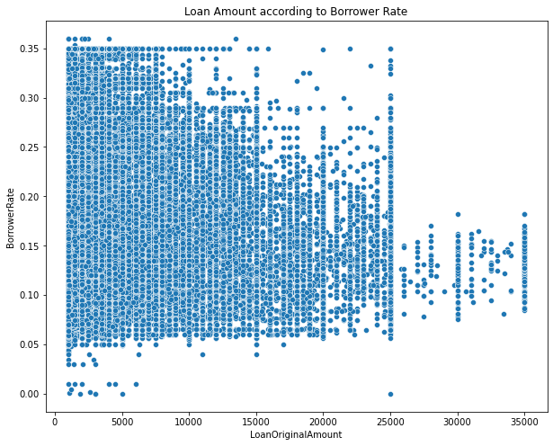

```python
# colors = sns.color_palette('pastel')[0:5]
plt.figure(figsize=(10,8))
# sns.scatterplot(x=df_main.LoanOriginalAmount, y=df_main.MonthlyLoanPayment)
sns.scatterplot(data = df_main, x = 'LoanOriginalAmount', y = 'BorrowerRate').set_title('Loan Amount according to Borrower Rate')
plt.show()
```

#### Observation 2:

> The Highest the loan is, the Borrower rate decrease. Prosper ensure they are getting best interest rate to cover any futher lost from those who cannot pay

#### Question 3:

#### Visualization 3

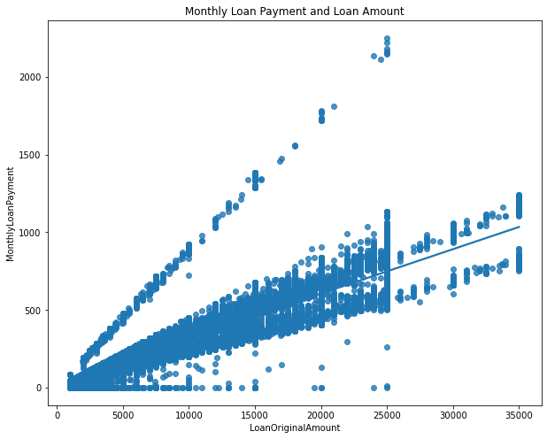

```python
# colors = sns.color_palette('pastel')[0:5]
plt.figure(figsize=(10,8))
# sns.scatterplot(x=df_main.LoanOriginalAmount, y=df_main.MonthlyLoanPayment)
sns.regplot(data = df_main, x = 'LoanOriginalAmount', y = 'MonthlyLoanPayment').set_title('Monthly Loan Payment and Loan Amount')
plt.show()
```

#### Question 4: Following the Loan Original Amount based on Occupation what group of people have high demand impact as Borrower ?

#### Visualization 4

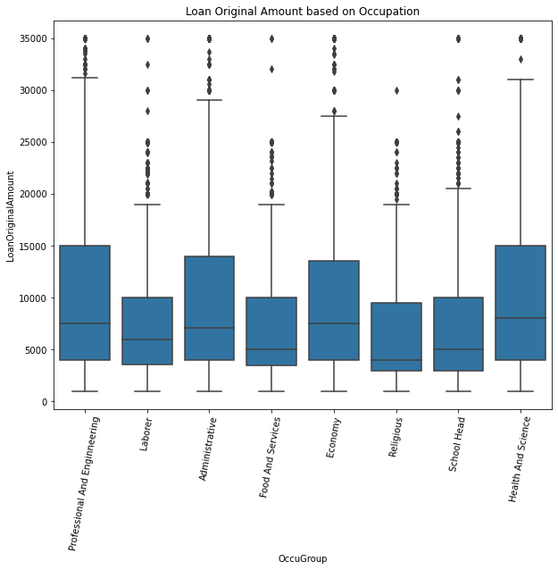

```python
plt.figure(figsize=(10,8))
base_color = sns.color_palette()[0]
sns.boxplot(data=df_main, y='LoanOriginalAmount', x='OccuGroup', color=base_color).set_title('Loan Original Amount based on Occupation')
plt.xticks(rotation=80)
plt.show()
```

#### Observation 4:

> The most in demand and highest group in need of loans are : (Health And Science, Professional And Engineering)

```python
df_false = df_main[df_main.IncomeVerifiable == False].groupby(['EmploymentStatus']).IsBorrowerHomeowner.value_counts()
df_false
```

```
EmploymentStatus  IsBorrowerHomeowner
Employed          False                   681
                  True                    333
Full-time         False                   288
                  True                    227
Not available     False                    24
                  True                     11
Not employed      False                    18
                  True                      3
Part-time         False                    69
                  True                     13
Retired           False                     3
Self-employed     False                  1735
                  True                   1471
Name: IsBorrowerHomeowner, dtype: int64
```

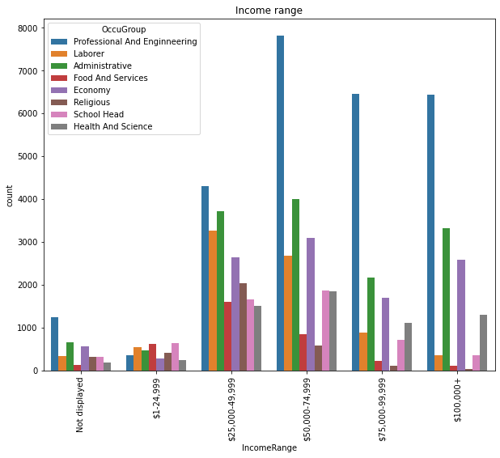

```python
order_income_range = ['Not displayed', '$1-24,999','$25,000-49,999', '$50,000-74,999', '$75,000-99,999', '$100,000+']
plt.figure(figsize=(10,8))
sns.countplot(data= df_main, x = 'IncomeRange', hue='OccuGroup', order= order_income_range).set_title('Income range')
plt.xticks(rotation=90)
plt.show()
# Ordorner le graphique
```

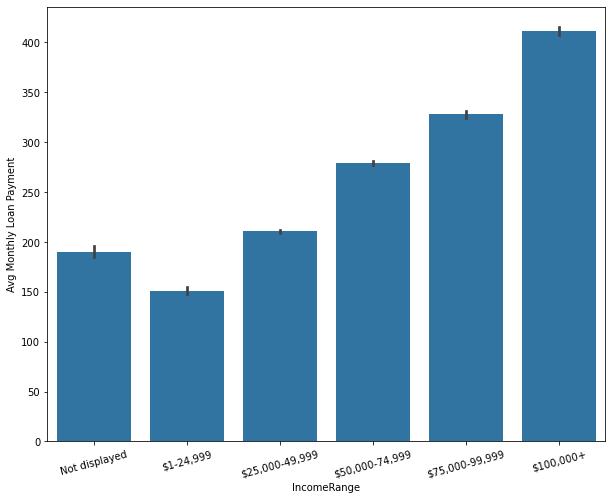

```python
plt.figure(figsize=(10,8))
sns.barplot(data=df_main, x='IncomeRange', y='MonthlyLoanPayment', color= base_color,order= order_income_range)
plt.xticks(rotation=15);
plt.ylabel('Avg Monthly Loan Payment')
plt.show()
```

#### Oservation 5:

> As the income range is growing, the average value on monthly is growing. So nothing really critical to observe. We can just say that it is a normal pattern for their loan.

### Talk about some of the relationships you observed in this part of the investigation. How did the feature(s) of interest vary with other features in the dataset?

> During this evaluation through bivariate exploration we can see that the monthly loan payment increase depending on the salary range. Also Health, Science, Professional And Engineering group persons are requesting more loans than others group.

### Did you observe any interesting relationships between the other features (not the main feature(s) of interest)?

> A Quick observation of people without verifiable income are not really those owning home. Is there any specific reason explaining the loan attributed to people without income verifiable ? Is Delinquencies Last 7 Years not valuable for them.

## Multivariate Exploration

> In this section will try to undestand the relation between our main features

#### Question 1 : What is the delinquencies impact for no income verifiable on loan

#### Visualization

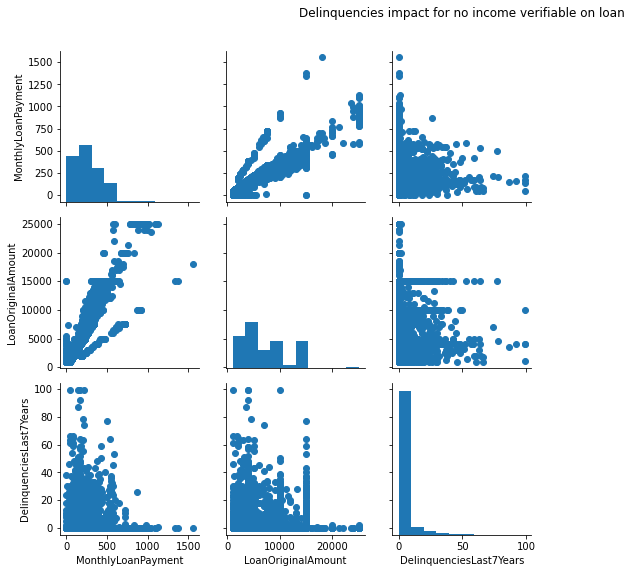

```python
plt.figure(figsize=(10,10))
g = sns.PairGrid(data = df_main[df_main.IncomeVerifiable == False], vars = ['MonthlyLoanPayment', 'LoanOriginalAmount', 'DelinquenciesLast7Years'])
g.map_diag(plt.hist)
g.map_offdiag(plt.scatter)
plt.xticks(rotation=90);
plt.title('Delinquencies impact for no income verifiable on loan', loc= 'center', pad =200)
plt.show()
```

#### Observation 1:

> All the graphics are following the same pattern as with all entries from the dataset. So can not yet conclude why this specific group of people are getting the loan.

#### Question 2: Based on the Borrower, let's explore if Loan payment is good for Prosper Company ?

#### Visualisation 2

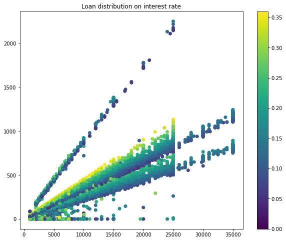

```python
plt.figure(figsize=(10, 8))
plt.scatter(data = df_main, x = 'LoanOriginalAmount', y = 'MonthlyLoanPayment', c = 'BorrowerRate')
plt.colorbar()
plt.title('Loan distribution on interest rate')
plt.show()
```

### Talk about some of the relationships you observed in this part of the investigation. Were there features that strengthened each other in terms of looking at your feature(s) of interest?

> Overall our exploration there the loan is attribute to people following their group, the income range. They also take of everything to avoid loast for the company. Like that, the Borrower following his salary range pay their monthly loan accodingly.

### Were there any interesting or surprising interactions between features?

> There is not really something specific explaining the loan for people without income verifiable. We might later explore other variable to correctly this specific choice four this group of Borrowers.

## Conclusions

#### Step 1 :

> Prosper Loan Data set contain 113 937 loan with 81 variables to describe each observation about the borrower, the loan. Because of the large number of variable that we have, my first thougth was to sort the relation between all varaible to see if we are in case of merged dataset or informatio from different source. By following this exploration I found that we some variables have more thant **25%** of their values null.